# Spectral clustering

E.B.

## Základné pojmy z algebry

**Vlastné čísal a vlastné vektory** matice $\mathbf{Av=\lambda v}$

Ortogonálne vektory $uv=0$ nazývame ortonormálne, ak $\mathbf{||u||=||v||=1}$

Matice $A,B$ sú **podobné**, ak existuje regularna matica $S$, kde $A=SBS^{-1}$

Reálna **symetrická** matica $A$ je podobná **diagonálnej**, vlastne čísla sú reálne.

Ak je symetrická matica **pozitívne semidefinitná** $\mathbf{v^\top Av\ge 0}$, tak $\mathbf{0\le\lambda_1\le\dots\lambda_k}$ kde $\mathbf{k}$ je hodnosť matice.

## Príklady

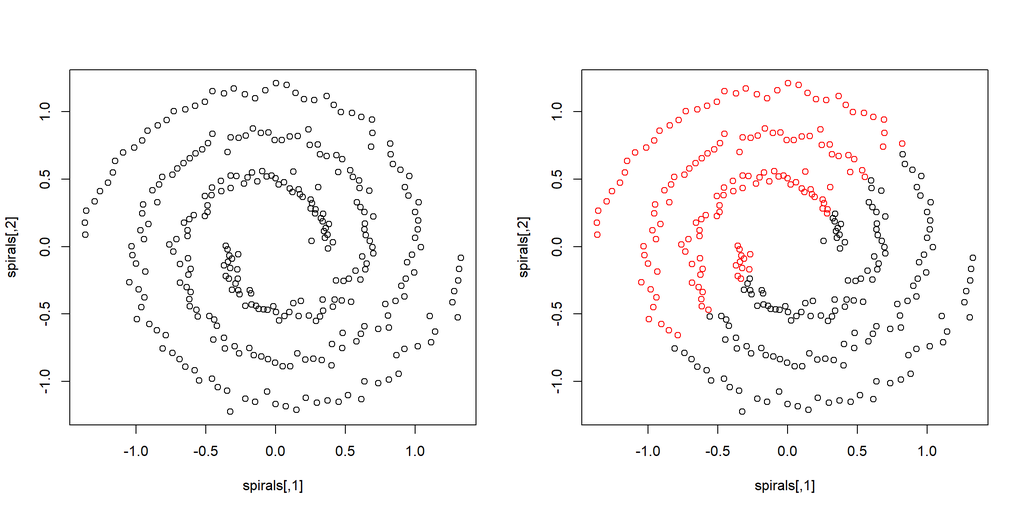

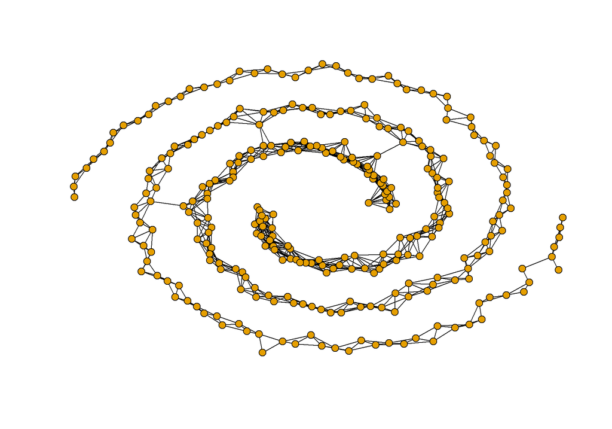

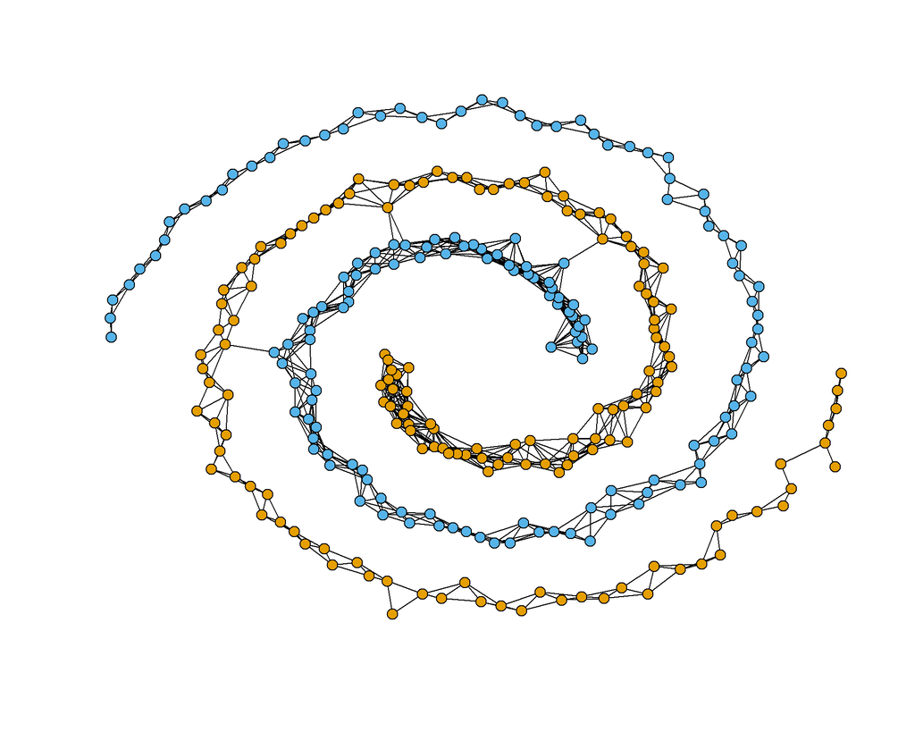

## Základná myšlienka grafovej reprezentácie:

**Cieľ:** rozdelenie vrcholov do zhlukov tak, aby sme minimalizovali hrany medzi zhlukmi a zároveň boli tieto zhluky vyvážené.

Teda na rozdiel úlohy minimálneho rezu v grafe, ktorá potenciálne ústi ku separácii jedného vrchola v našom prípade (H), sa snažíme dodať navyše podmienku znevýhodňujúcu riešenia s výrazne rozdielnými veľkostami zhlukov.

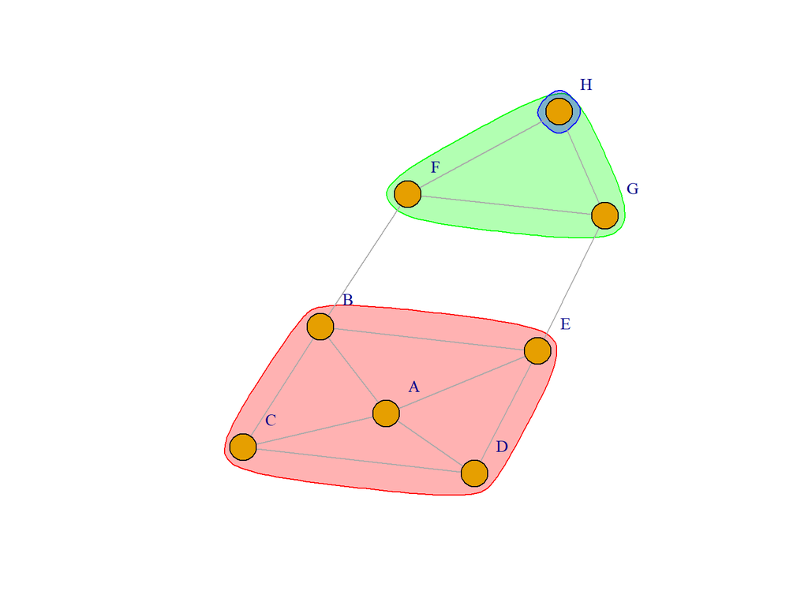

## Zakódujme úlohu

Uvažujme na začiatok graf bez váh hrán a rozdelenie na dva zhluky.

1. Minimalizujem počet hrán medzi zhlukmi, teda pre zvolené rozdelenie chceme vyhjadriť počet hrán medzi zhlukmi.
   - rozdelenie do zhlukov pomocou indikačného vektora $f=(1,1,1,1,1,-1,-1,-1)$
   - **upravená** matica incidencie $H$ *(vrcholovo-hranová)*
     - pre jeden z koncových vrcholov každej hrany sa použije $-1$
       $$\begin{array}{l|ccccccccccccc}
       & ab & ac & ad & ae & bc & be & bf & cd & de & eg & fg & fh & gh\\
       A & 1 & 1 & 1 & 1 & 0 & 0 & 0 & 0 & 0 & 0 & 0 & 0 & 0\\
       B & -1 & 0 & 0 & 0 & 1 & 1 & 1 & 0 & 0 & 0 & 0 & 0 & 0\\
       C & 0 & -1 & 0 & 0 & -1 & 0 & 0 & 1 & 0 & 0 & 0 & 0 & 0\\
       D & 0 & 0 & -1 & 0 & 0 & 0 & 0 & -1 & 1 & 0 & 0 & 0 & 0\\
       E & 0 & 0 & 0 & -1 & 0 & -1 & 0 & 0 & -1 & 1 & 0 & 0 & 0\\
       \hline
       F & 0 & 0 & 0 & 0 & 0 & 0 & -1 & 0 & 0 & 0 & 1 & 1 & 0\\
       G & 0 & 0 & 0 & 0 & 0 & 0 & 0 & 0 & 0 & -1 & -1 & 0 & 1\\
       H & 0 & 0 & 0 & 0 & 0 & 0 & 0 & 0 & 0 & 0 & 0 & -1 & -1\\
       \end{array}$$

## Vybalansovanie zhlukov

Pre rozdelenie $f$ by sme mali zaviesť

- Modifikovaním indikačného vektora

$$f_i=\Bigg\{^{\sqrt{\frac{|\bar{A}|}{|A|}} \quad \text{pre} \quad v_i \in A}_{-\sqrt{\frac{|A|}{|\bar{A}|}} \quad \text{pre} \quad v_i \bar{A}}$$

- hrany budú započítané s váhou $( \frac{|A|}{|\bar{A}|} + \frac{|\bar{A}|}{|A|})$, navyše $\quad \sum_{i=1}^{n}{f_i}=\sum_\limits{i\in A}{\sqrt{\frac{|\bar{A}|}{|A|}}}-\sum_\limits{i\in \bar{A}}{\sqrt{\frac{|A|}{|\bar{A}|}}}=|A|\sqrt{\frac{|\bar{A}|}{|A|}}-|\bar{A}|\sqrt{\frac{|A|}{|\bar{A}|}}=0$ a teda $f \perp (1,\dots,1)$ a zároveň $||f||^2 =n$ pre $|V|=n$.

Úloha $f^\top L f \rightarrow \min_{A \subset V}$, kde $L=HH^\top = D-A$ pre spomínané podmienky je NP ťažká. $D$ je diagonálna matica so stupňami vrcholov na hlavnej diagonále, $A$ je matica susednosti graf

## Zjemnenie podmienky

$\min f^\top L f$ za predpokladu $f \in R^n$ pre $f \perp (1,\dots,1) \quad f^\top f=n$

### Rayleigh Ritz

Nech $A$ je symetrická matica $n \times n$ s vlastnými číslami $\lambda_1\le\lambda_2\le\dots\le\lambda_n$ a $u_1,\dots,u_n$ je odpovedajúca ortonormálna báza vlastných vektorov $A$ potom
$$\min\limits_{x\neq 0} \frac{x^\top A x}{x^\top x}=\lambda_1$$
kde sa mininum dosahuje pre $x=u_1$. Resp.
$$\min\limits_{x\neq 0,x\in\{u_1\dots,u_{i-1}\}^\bot} \frac{x^\top A x}{x^\top x}=\lambda_i$$
kde sa mininum dosahuje pre $x=u_i$.

Vlastný vektor prislúchajúci matie $L$ dobre aproximuje riešenie.

## Najdenie k zhlukov pre $K>2$

4. Pre každý zhluk samostatný indikačný vektor $(f^1,\dots,f^k)=F$ kde
   $$f^i_j=\bigg\{^{\sqrt{\frac{1}{|A_i|}} \quad \text{pre} \quad v_j \in A_i}_{0 \quad \text{inak}}$$
   Indikačné vektory sú navzájom ortogonálne teda $F.F^\top =I$

Minimalizujeme $\sum_1^kf^i.L.f^{i\top}$ teda minimalizujeme súčet prvkov na hlavnej diagonale $\sum_i^k(FLF^\top)_{ii}=Tr(FLF^\top)$

Opä je nutné zjenenie podmienok

## Zjemnenie podmienok pre k>2

$\min_\limits{F\in \mathcal{R}^{r\times n}} Tr(FLF^\top)$ za predpokladu $F.F^\top =I$

### Poincaré separation theorem

Nech $A$ je symetrická matica $n \times n$ s vlastnými číslami $\lambda_1\le\lambda_2\le\dots\le\lambda_n$ a $R$ je matica $n\times m$ taká, že $R^\top R=I$ pre $m\le n$, a $B=R^\top AR$ s vlastnými číslami $\mu_1\le\mu_2,\dots\le\mu_m$.

Potom:

1.
$$\lambda_i\le\mu_i\le\lambda_{n-m+i},\space i= 1,\dots,m$$

2.Ak $\lambda_i=\mu_i$ potom existuje vlastný vektor $v$ matice $B$ s vlastným číslom $\mu_i$ pričom $Rv$ je vlastným vektorom $A$ s vlastným číslom $\lambda_i$

### Dôsledok

$$\lambda_1+\dots+\lambda_i\le Tr(R^\top AR)\le\lambda_{n-m+1}+\dots \lambda_n$$

Riešenie aproximuje k vlastných vektorov prislúchajúcich najmenším k vlastným číslam. Na identifikáciu k zhlukov aplikujeme napr. na body tvorené jdenotlivými zložkami daných vektorov.

## Vážené hrany

V prípade váh hrán je $|A^j|$ nahradená $Vol(A^j)=\sum d_i$ pre $v_i \in A^j$

$$f_i=\Bigg\{^{\sqrt{\frac{Vol(A)}{Vol(\bar{A})}} \quad \text{pre} \quad v_i \in\bar{A}}_{-\sqrt{\frac{Vol(\bar{A})}{Vol(A)}} \quad \text{pre} \quad v_i \in A}$$

Optimalizačná úloha pre k=2 má tvar:

$\min f^\top L f$, kde $f^\top D f =vol(V)$ a $Df\perp (1,\dots,1)$.

Ak položíme $f=D^{-\frac{1}{2}}g$ minimalizujeme

$\min g^\top D^{-\frac{1}{2}} LD^{-\frac{1}{2}}g$, kde $g^\top g =vol(V)$ a $D^{\frac{1}{2}}g\perp (1,\dots,1)$.

Riešením je vlastný vektor odpovedajúci najmenšiemu nenulovému vlastnému číslu symetrickej Laplasovej matici
$$L_{sym}=D^{-\frac{1}{2}} LD^{-\frac{1}{2}}$$

## Ako získať vlastné vektory pri veľkých maticiach

Motivácia je “Power iteration” Pre maticu $A$ $n \times n$ a náhodný vektor $v$ postupnosť $v,Av.A^2v,A^3v,\dots$ konverguje ku dominantnému vlastnému vektoru.

Priestor $[v,Av.A^2v,A^3v,\dots,A^mv]$ sa nazýva Kyrlov podpriestor matice $A$ vzhľadom na vektor $v$ oznacuje sa $K_m(A,v)$

### Poincaré

… pre $B=R^\top AR$ kde $R^\top R=I$ s vlastnými číslami $\mu_1\le\mu_2,\dots\le\mu_m$.

$$\lambda_i\le\mu_i\le\lambda_{n-m+i},\space i= 1,\dots,m$$

Vhodnou modifikáciou vytvárania bázy (ortogonalnej) tohto priestoru v jednotlivých iteráciach vieme aproximovať aj ďalšie vlastné vektory.

Viď. symetricke matice Lanczosová metóda resp. Arnoldiho

Rýchlejšie konverguju v krajoch spektra ako v strede, vieme efektívnejšie aproximovať prvých $k$ vlastných čísel ako robiť spektrálny rozklad.

## Konduktancia a Cheeger-ová nerovnosť (ako dobrý je rez?)

Pre graf G definujeme konduktanciu ako
$$\phi_G=\min\limits_{S\subset V}\frac{\delta(S)}{\min\{vol(S),vol(\bar S)\}}$$
kde $\delta (S)$ suma váh hrán rezu $S$ a $\bar{S}$

Nech $G$ súvislý graf s konfuktaciou $\phi(G)$ a $\gamma$ je konduktancia rezu spetrálneho algoritmu aplikovaného na normalizovanej Laplacovej matici $\cal{L}$ s druhým najmenším vlastným číslom $\lambda_2$. Potom platí:
$$\frac{\lambda_2}{2}\le\phi(G)\le\gamma\le\sqrt{2\lambda_2}$$

## Spektrálny rozklad na datasete spoluautorov

IGRAPH 3585f10 U— 1589 2742 – + attr: id (v/n), label (v/c), value (e/n)

Vytvoríme indukovaný podgraf z jedného komponenu

```
## IGRAPH 82ec71b U--- 379 914 --
## + attr: id (v/n), label (v/c), value (e/n)
```

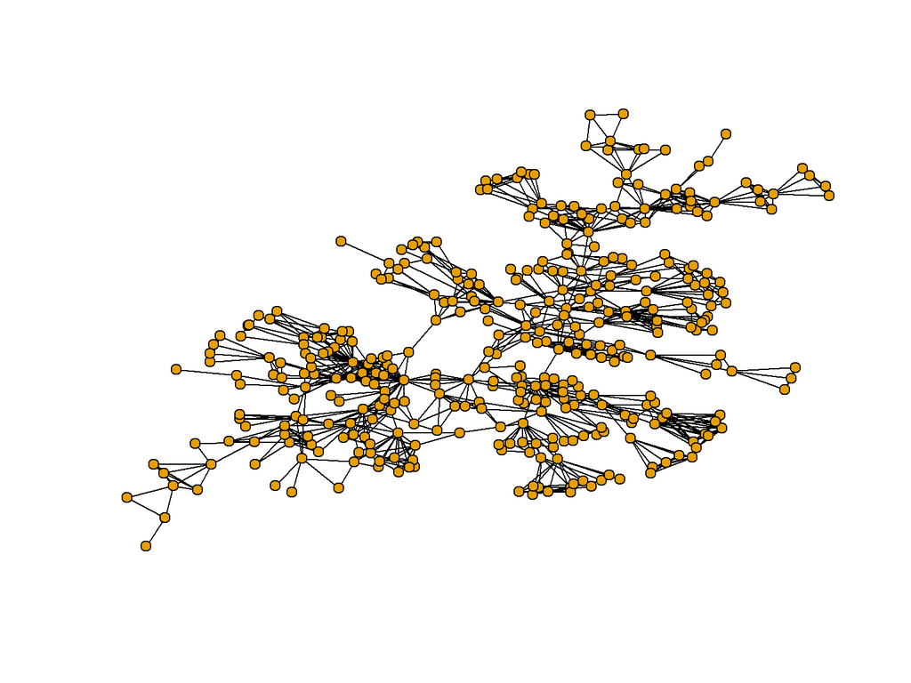

## Spektrum Laplacovej matice

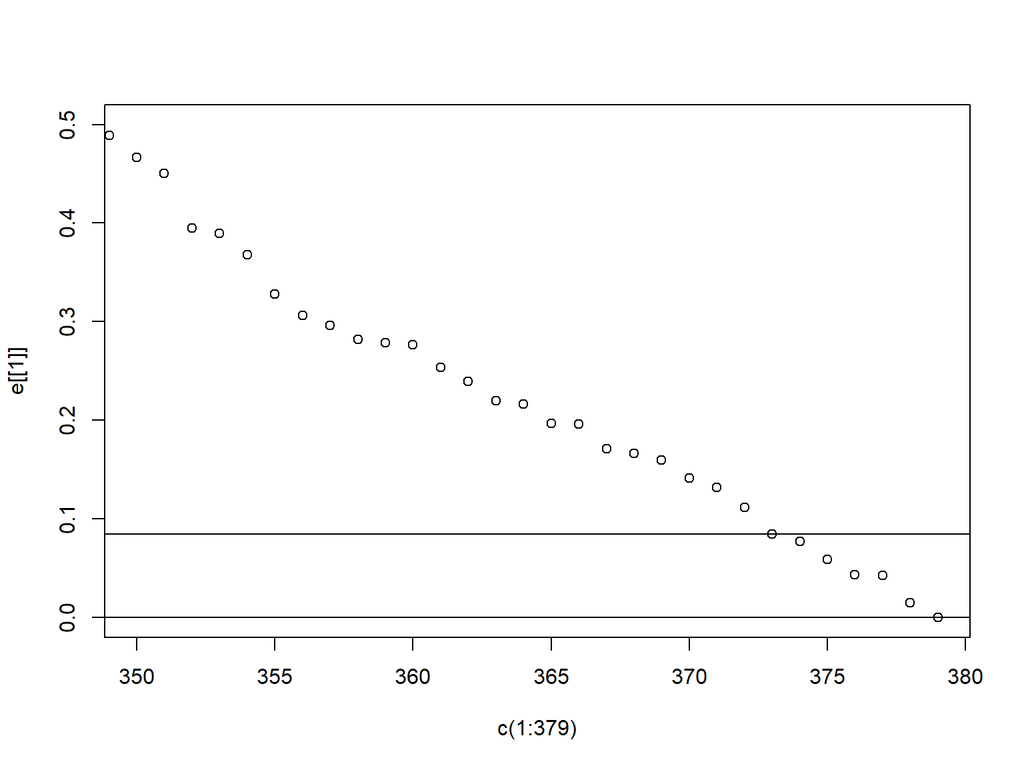

## Rez podľa druhého vlastného vektora (kladné zložky identifikujú jede kláster, záporné druhý)

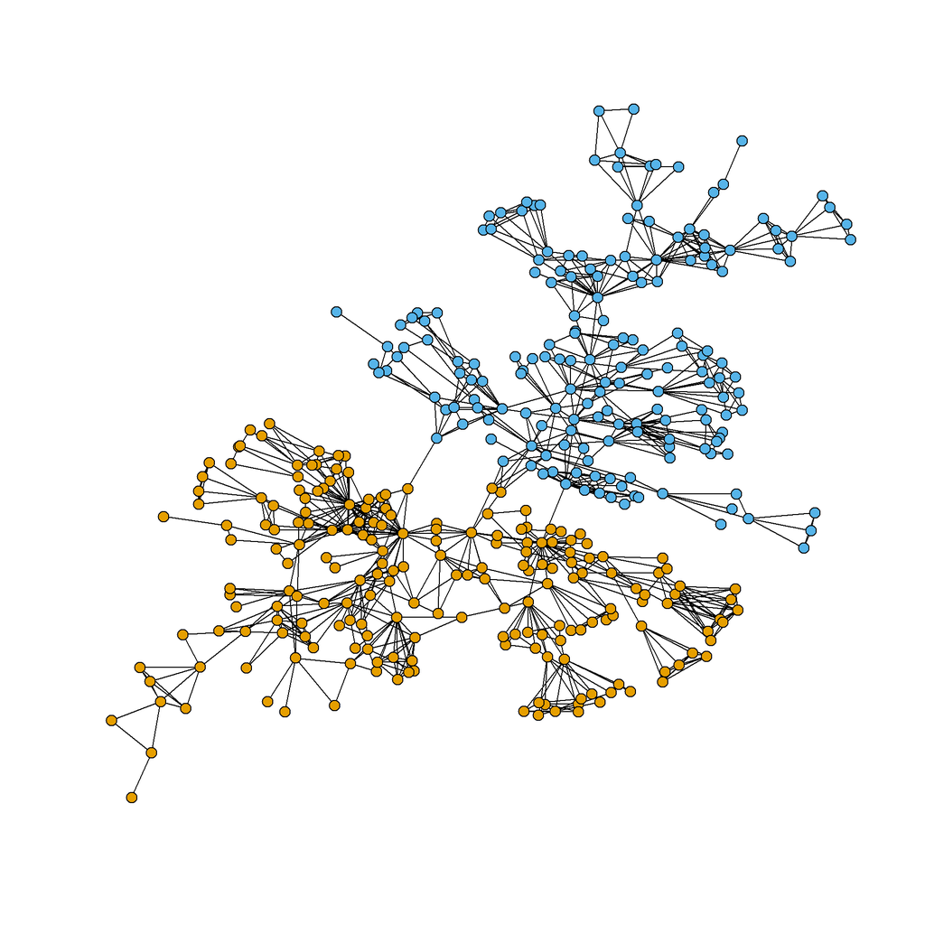

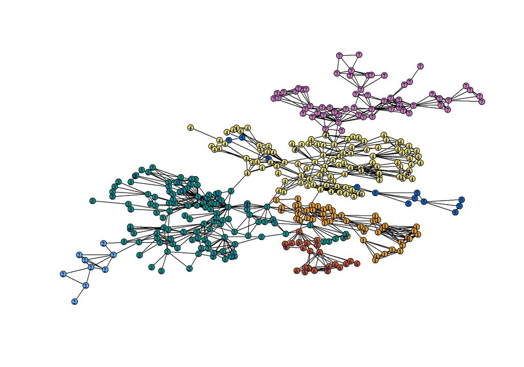

## Detail časti grafu

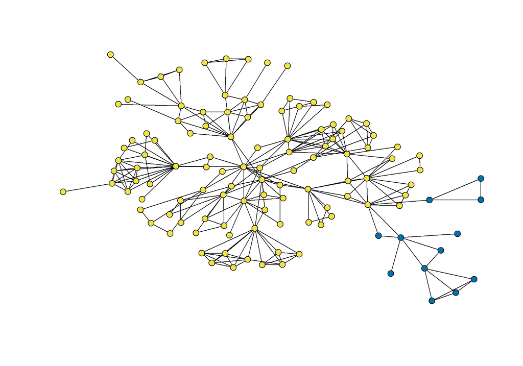

## Ďalší výrazný odskok je pri 27 vlastnom čísle teda príklad ako to klastruje ak zoberiem viac vektorov s použitím k-means

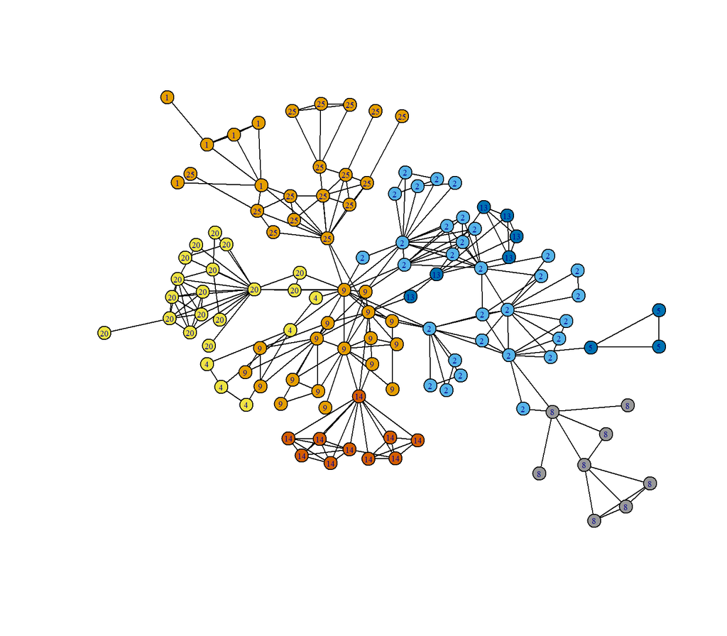

## Porovnanie so skutočným rozdelením na komunity

-rozdelenie jedného športového klubu na samostatné kluby

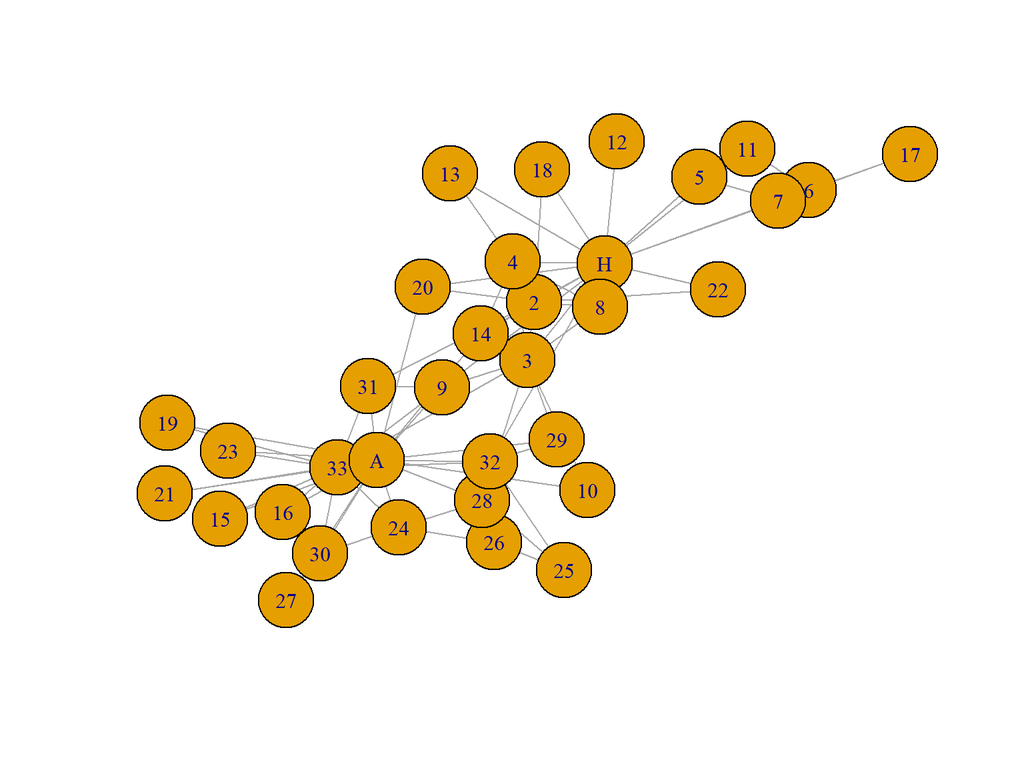

## Spektrum

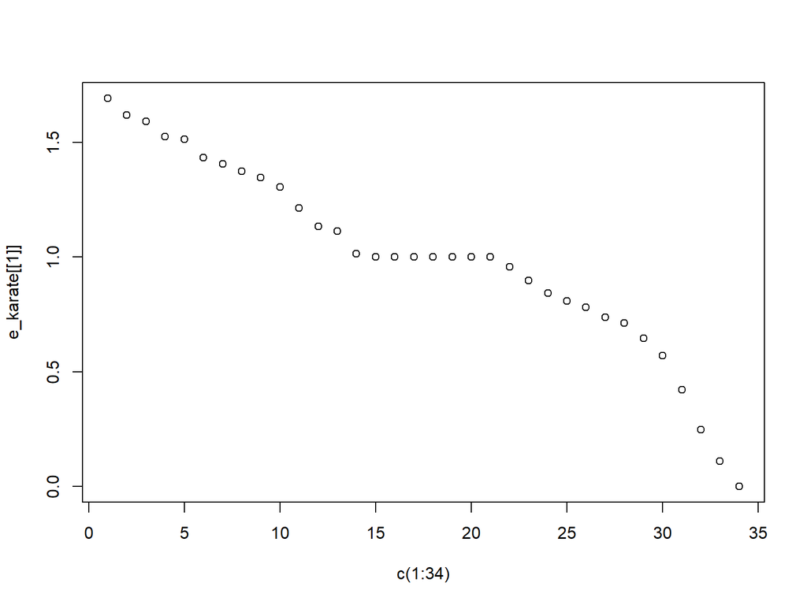

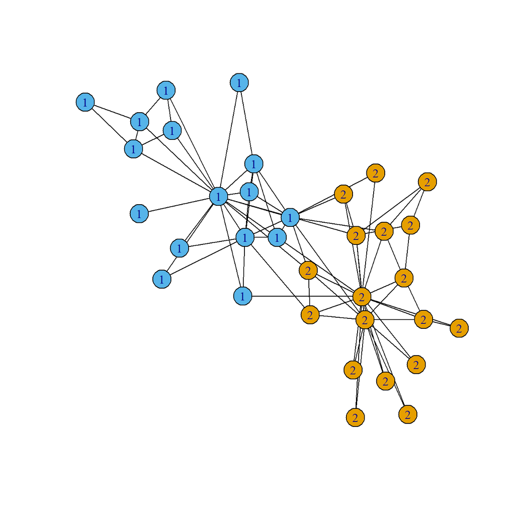